# Praca domowa ze wstępu do uczenia maszynowego nr 2

Marceli Korbin

23 marca 2020

```r
knitr::opts_chunk$set(echo=TRUE, cache=TRUE)
library(plyr)
library(dplyr)
library(mlr)
library(mice)
```

```r
library(ggplot2)
allegro <- read.csv("https://www.dropbox.com/s/360xhh2d9lnaek3/allegro-api-transactions.csv?dl=1")
```

## Wstęp

Na ramce danych *allegro* (o portalu Allegro) będę się bawić w kodowanie zmiennych kategorycznych i uzupełnianie braków.

## Część 1: kodowanie zmiennych kategorycznych

### Target encoding

Kolumna *it_location* przechowuje dane o miejscu wystawienia produktu na sprzedaż na stronie Allegro. Jest w ten sposób całkiem informatywna, ale może zajmować niepotrzebną pamięć.

```r
allegro1 <- allegro
# usuńmy może czynniki, żeby się łatwiej pracowało, bo z nimi, to tak nie do końca się da takie rzeczy
i <- sapply(allegro1, is.factor)
allegro1[i] <- lapply(allegro1[i], as.character)
object.size(allegro1$it_location)
```

```
## 4046752 bytes
```

Przekształcimy te informacje względem kolumny *price*, czyli informacji o cenie produktu. Średnią ceną scharakteryzujemy wówczas występujące lokalizacje.

```r
lok_ceny <- allegro1 %>% group_by(it_location) %>% summarise(srednia=mean(price, na.rm=TRUE))
# liczymy średnie ceny produktów z występujących lokalizacji
allegro1$it_location <- mapvalues(allegro1$it_location, from=lok_ceny$it_location, to=lok_ceny$srednia)
# kodujemy funkcją z plyr
```

Jak to teraz wygląda?

```r
object.size(allegro1$it_location)
```

```
## 3784216 bytes
```

Kolumna *it_location* nie tylko zajmuje mniej pamięci, ale i daje teraz podgląd na “spodziewaną” cenę w danym miejscu. Jest to o tyle lepsze od one-hot encodingu, że zachowuje jakąś charakterystykę. A skoro mówimy o one-hot encodingu…

### One-hot encoding

…to go przetestujemy na kolumnie *main_category*.

```r
allegro2 <- allegro
object.size(allegro2$main_category)
```

```
## 1682536 bytes
```

```r
# tutaj też pozbędziemy się czynników
i <- sapply(allegro2, is.factor)
allegro2[i] <- lapply(allegro2[i], as.character)
kategorie <- unique(allegro2$main_category)
# unikalne kategorie
kat1h <- kategorie
for (x in 1:length(kat1h))
  kat1h[x] <- list(kat1h[x]==kategorie)
allegro2$main_category <- mapvalues(allegro2$main_category, from=kategorie, to=kat1h)
# main_category staje się zbiorem list booleanów
object.size(allegro2$main_category)
```

```
## 77283728 bytes
```

To był jeden sposób. Pakiet *mlr* (nie jego zastępca *mlr3*) posiada tymczasem funkcję *createDummyFeatures*, która wykonuje one-hot encoding, ale porozsadzany na osobne kolumny, a nie upakowany w jedną. Istnieją dwie metody: *1-of-n*, po której każda kategoria ma swoją kolumnę i *reference*, tworząca o jedną kolumnę mniej - jeśli jakiś rekord nie reprezentuje żadnej kategorii z zakodowanych, to domyślnie należy do tej ostatniej (kategoria-widmo).

Kodowanie w praktyce:

```r
# już nie psujmy czynników, bo dla tych metod akurat są one kluczowe
allegro4 <- createDummyFeatures(allegro, method="1-of-n", cols="main_category")[1:10, -c(1:13)]
colnames(allegro4) <- c(1:27) # nazwy kolumn musiałem zmienić, bo psuły kompilację
head(allegro4)
```

```
##   1 2 3 4 5 6 7 8 9 10 11 12 13 14 15 16 17 18 19 20 21 22 23 24 25 26 27
## 1 0 0 0 0 0 0 0 0 0  0  0  0  1  0  0  0  0  0  0  0  0  0  0  0  0  0  0
## 2 0 0 0 0 0 0 0 0 0  0  0  0  0  0  0  0  0  0  1  0  0  0  0  0  0  0  0
## 3 0 0 0 0 0 0 1 0 0  0  0  0  0  0  0  0  0  0  0  0  0  0  0  0  0  0  0
## 4 0 0 0 0 0 0 0 0 0  0  0  0  0  0  1  0  0  0  0  0  0  0  0  0  0  0  0
## 5 0 0 0 0 0 0 0 0 0  0  0  0  0  0  0  0  0  0  1  0  0  0  0  0  0  0  0
## 6 0 0 0 0 0 0 0 0 0  0  0  0  0  0  0  0  0  0  1  0  0  0  0  0  0  0  0
```

```r
allegro4 <- createDummyFeatures(allegro, method="reference", cols="main_category")[1:10, -c(1:13)]
colnames(allegro4) <- c(1:26)
head(allegro4)
```

```
##   1 2 3 4 5 6 7 8 9 10 11 12 13 14 15 16 17 18 19 20 21 22 23 24 25 26
## 1 0 0 0 0 0 0 0 0 0  0  0  1  0  0  0  0  0  0  0  0  0  0  0  0  0  0
## 2 0 0 0 0 0 0 0 0 0  0  0  0  0  0  0  0  0  1  0  0  0  0  0  0  0  0
## 3 0 0 0 0 0 1 0 0 0  0  0  0  0  0  0  0  0  0  0  0  0  0  0  0  0  0
## 4 0 0 0 0 0 0 0 0 0  0  0  0  0  1  0  0  0  0  0  0  0  0  0  0  0  0
## 5 0 0 0 0 0 0 0 0 0  0  0  0  0  0  0  0  0  1  0  0  0  0  0  0  0  0
## 6 0 0 0 0 0 0 0 0 0  0  0  0  0  0  0  0  0  1  0  0  0  0  0  0  0  0
```

## Część 2: uzupełnianie braków

Ograniczamy zbiór do trzech kolumn numerycznych *price*, *it_seller_rating* i *it_quantity*. Będziemy kilka razy wyrzucać losowe dane z listy i z powrotem je imputować metodą *norm.predict* z pakietu *mice*. Celem jest sprawdzenie poprawności tej metody (zgodnie z propozycją w treści p.d., skorzystam z RMSE - pierwiastka błędu średniokwadratowego).

Przebieg eksperymentu:  
* 10 razy:  
* usuwam losowe 10% wartości it_seller_rating  
* imputuję (3 iteracje po 3 imputacje, razem wyjdzie 90 imputacji)  
* notuję miarę poprawności  
* 10 razy:  
* usuwam losowe 10% wartości it_seller_rating i inne losowe 10% it_quantity  
* imputuję (jw., razem imputacji będziemy mieli zrobione aż 180)  
* notuję miarę poprawności

```r
allegro3 <- allegro[, c("price", "it_seller_rating", "it_quantity")]

rmse1 <- c()
rmse2 <- c()
for (take in 1:10){
  emptied <- sample(1:nrow(allegro3), nrow(allegro3)/10)
  al_empty <- allegro3
  al_empty[emptied, 2] <- NA
  al_impute <- mice(al_empty, method="norm.predict", m=3, maxit=3)
  al_full <- complete(al_impute, 1)
  rmse1 <- c(rmse1, measureRMSE(allegro3$it_seller_rating, al_full$it_seller_rating))
}
sd(rmse1)
```

```
## [1] 77.70253
```

```r
for (take in 1:10){
  emptied <- sample(1:nrow(allegro3), nrow(allegro3)/10)
  al_empty <- allegro3
  al_empty[emptied, 2] <- NA
  emptied <- sample(1:nrow(allegro3), nrow(allegro3)/10)
  al_empty[emptied, 3] <- NA
  al_impute <- mice(al_empty, method="norm.predict", m=3, maxit=3)
  al_full <- complete(al_impute, 1)
  rmse2 <- c(rmse2, measureRMSE(allegro3$it_seller_rating, al_full$it_seller_rating))
}
sd(rmse2)
```

```
## [1] 107.2515
```

Jak się konkretnie różniły te miary? Nakreślę teraz dwa wykresy, pokazujące różnicę między średnią i każdą z obserwacji. W każdym wykresie oprócz punktów dodaję trzy linie symbolizujące zakres odchylenia standardowego.

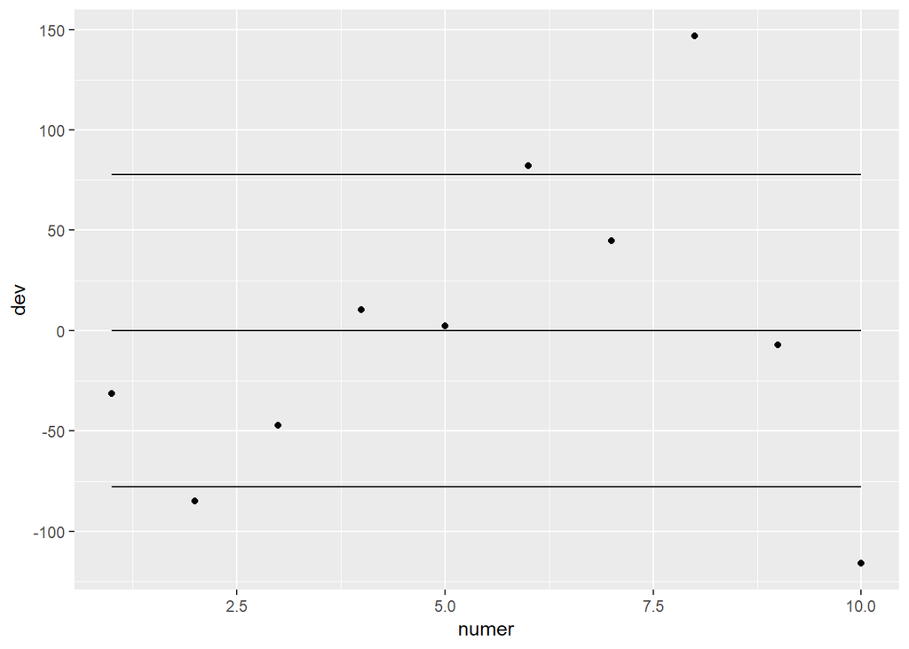

```r
odchylenie <- function(observ) ggplot(as.data.frame(cbind(numer=1:10, dev=observ-mean(observ))),
                                      aes(x=numer, y=dev)) + geom_point() +
  geom_line(aes(y=0)) + geom_line(aes(y=-sd(observ))) + geom_line(aes(y=sd(observ)))
# etap z imputacją jednej kolumny
odchylenie(rmse1)
```

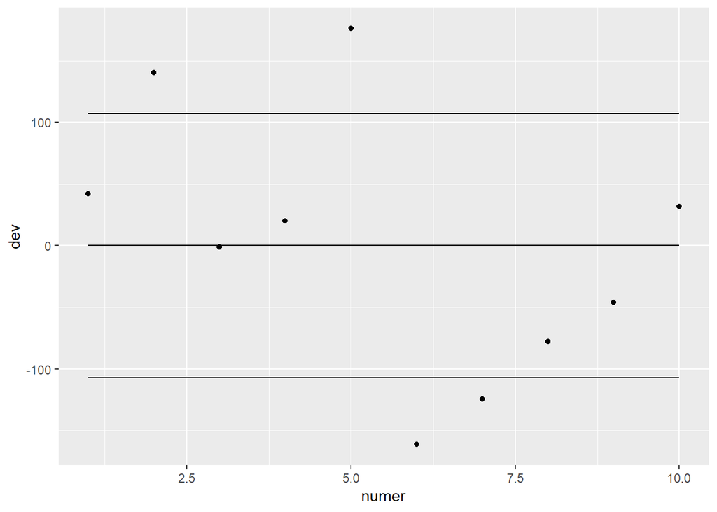

```r
# etap z imputacją dwóch kolumn
odchylenie(rmse2)
```